# NOAA Storm Data Analysis

Anna M

2023-02-09

## Synposis

Storms and other severe weather events can cause both public health and economic problems for communities and municipalities. Many severe events can result in fatalities, injuries, and property damage, and preventing such outcomes to the extent possible is a key concern.

This project involves exploring the U.S. National Oceanic and Atmospheric Administration’s (NOAA) storm database. This database tracks characteristics of major storms and weather events in the United States, including when and where they occur, as well as estimates of any fatalities, injuries, and property damage.

The goal of this project is to reveal which types of storms cause the most damage in terms of both population health and economic cost.

## Data Import

```r
url <- "https://d396qusza40orc.cloudfront.net/repdata%2Fdata%2FStormData.csv.bz2"
download.file(url, destfile = "stormdata.csv.bz2", method = "curl")
stormdata <- read.csv("stormdata.csv.bz2")
```

## Data Processing

Below, I will show my steps for how I approached data processing with respect to the two questions I am aiming to answer.

## Q1: Across the United States, which types of events (as indicated in the EVTYPE variable) are most harmful with respect to population health?

First, I am going to select relevant data (Event Type, Fatalities, Injuries).

```r
library(dplyr)
harmful <- stormdata
harmful <- harmful %>%
  select(EVTYPE, FATALITIES, INJURIES)
```

Then, I am going to calculate the total number of fatalities and injuries by event type.

```r
harmful_sum <- harmful
harmful_sum <- harmful_sum %>%
  group_by(EVTYPE) %>%
  summarise(fatalitySUM = sum(FATALITIES), injurySUM = sum(INJURIES))
```

Finally, I will find the maximum value of fatilities and injuries by event type.

```r
harmful_final <- harmful_sum[, c("EVTYPE", "fatalitySUM", "injurySUM")]

harmful_final <- harmful_final %>%
  arrange(desc(fatalitySUM))
head(harmful_final)
```

```
## # A tibble: 6 × 3
##   EVTYPE         fatalitySUM injurySUM
##   <chr>                <dbl>     <dbl>
## 1 TORNADO               5633     91346
## 2 EXCESSIVE HEAT        1903      6525
## 3 FLASH FLOOD            978      1777
## 4 HEAT                   937      2100
## 5 LIGHTNING              816      5230
## 6 TSTM WIND              504      6957
```

```r
harmful_final_inj <- harmful_final %>%
  arrange(desc(injurySUM))
head(harmful_final_inj)
```

```
## # A tibble: 6 × 3
##   EVTYPE         fatalitySUM injurySUM
##   <chr>                <dbl>     <dbl>
## 1 TORNADO               5633     91346
## 2 TSTM WIND              504      6957
## 3 FLOOD                  470      6789
## 4 EXCESSIVE HEAT        1903      6525
## 5 LIGHTNING              816      5230
## 6 HEAT                   937      2100
```

From this, we see that tornados are the most harmful to population health in terms of both total fatalities and total injuries.

## Q2: Across the United States, which types of events have the greatest economic consequences?

First, I am going to select the relevant data (Event Type, Property Damage, Crop Damage).

```r
economic <- stormdata
economic <- economic %>%
  select(EVTYPE, PROPDMG, CROPDMG)
```

Then, I am going to calculate the total cost of property and crop damage by event type.

```r
economic_harm <- economic
economic_harm <- economic_harm %>%
  group_by(EVTYPE) %>%
  summarise(propertySUM = sum(PROPDMG), cropSUM = sum(CROPDMG))
```

Finally, I will find the maximum cost of property and crop damage by event type.

```r
economic_final <- economic_harm[, c("EVTYPE", "propertySUM", "cropSUM")]

economic_final <- economic_final %>%
  arrange(desc(propertySUM))
head(economic_final)
```

```
## # A tibble: 6 × 3
##   EVTYPE            propertySUM cropSUM
##   <chr>                   <dbl>   <dbl>
## 1 TORNADO              3212258. 100019.
## 2 FLASH FLOOD          1420125. 179200.
## 3 TSTM WIND            1335966. 109203.
## 4 FLOOD                 899938. 168038.
## 5 THUNDERSTORM WIND     876844.  66791.
## 6 HAIL                  688693. 579596.
```

```r
economic_final_crop <- economic_final %>%
  arrange(desc(cropSUM))
head(economic_final_crop)
```

```
## # A tibble: 6 × 3
##   EVTYPE            propertySUM cropSUM
##   <chr>                   <dbl>   <dbl>
## 1 HAIL                  688693. 579596.
## 2 FLASH FLOOD          1420125. 179200.
## 3 FLOOD                 899938. 168038.
## 4 TSTM WIND            1335966. 109203.
## 5 TORNADO              3212258. 100019.
## 6 THUNDERSTORM WIND     876844.  66791.
```

From this, we see that the most costly events for property damage are tornados, at a total of $3,212,258.20. However, the most costly events for crop damage are hail, at a total of 579,596.26.

## Results

When looking at the most damaging types of events with respect to their impact on population health, it is clear to see that tornadoes are the most damaging. This visualisation will just show fatalities.

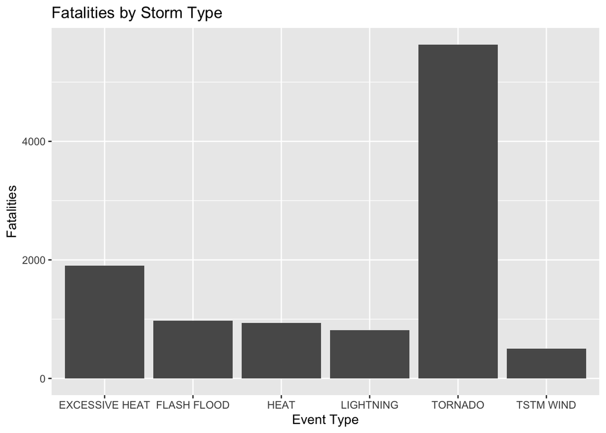

```r
library(ggplot2)

top_harmful <- head(harmful_final)

fatalitiesplot <- ggplot(top_harmful, mapping = aes(EVTYPE, fatalitySUM)) +
  geom_bar(stat = "identity") +
  labs(x = "Event Type", y = "Fatalities", title = "Fatalities by Storm Type")

print(fatalitiesplot)
```

When looking at the most expensive events by storm type, we have identified tornadoes and hail as the most damaging types of storms for property damage and crop damage, respectively. We can now see this visually.

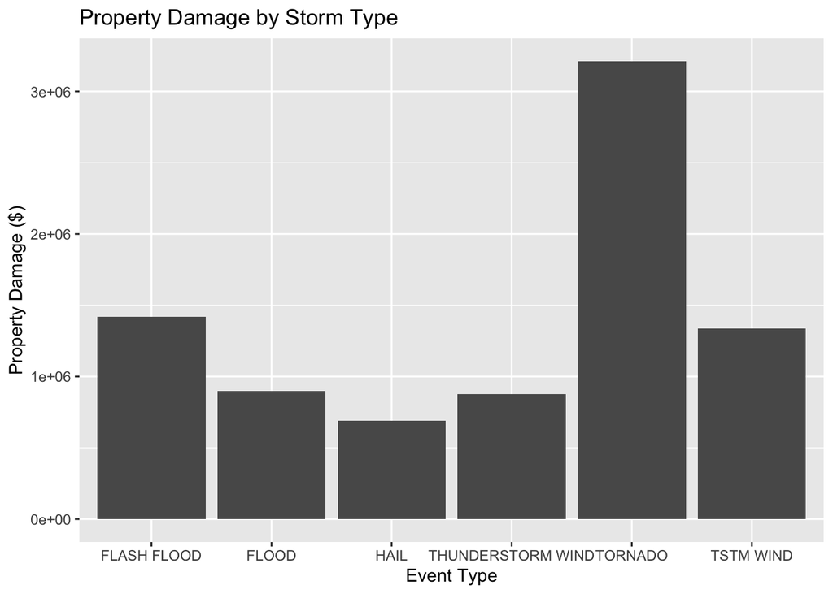

```r
top_economic <- head(economic_final)

propertyplot <- ggplot(top_economic, mapping = aes(EVTYPE, propertySUM)) +
  geom_bar(stat = "identity") +
  labs(x = "Event Type", y = "Property Damage ($)", title = "Property Damage by Storm Type")

print(propertyplot)
```

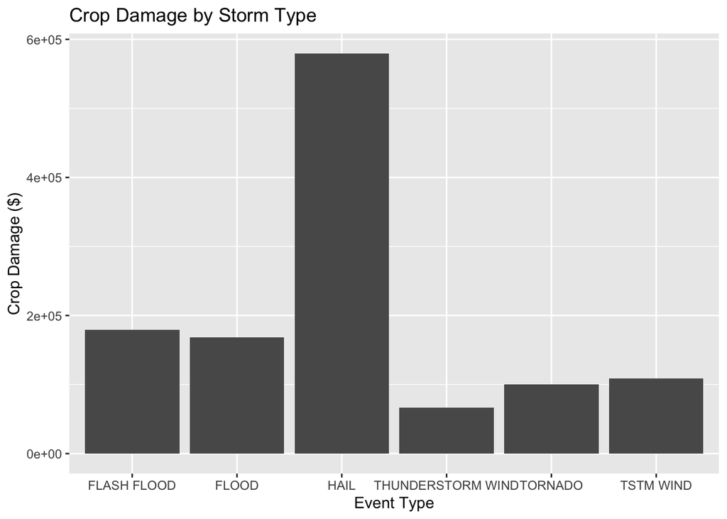

```r
cropplot <- ggplot(top_economic, mapping = aes(EVTYPE, cropSUM)) +
  geom_bar(stat = "identity") +
  labs(x = "Event Type", y = "Crop Damage ($)", title = "Crop Damage by Storm Type")

print(cropplot)
```